# Risk Factor Analysis

## Outcome Variable

**Outcome Variable:** whz

## Predictor Variables

**Intervention Variable:** perdiar6

**Adjustment Set:**

- arm
- sex
- W_mage
- meducyrs
- feducyrs
- hhwealth_quart
- hfoodsec
- W_mhtcm
- W_mwtkg
- W_mbmi
- W_birthwt
- W_birthlen
- W_nrooms
- month
- brthmon
- impfloor
- impsan
- safeh20
- delta_W_mage
- delta_meducyrs
- delta_feducyrs
- delta_hhwealth_quart
- delta_hfoodsec
- delta_W_mhtcm
- delta_W_mwtkg
- delta_W_mbmi
- delta_W_birthwt
- delta_W_birthlen
- delta_W_nrooms
- delta_month
- delta_brthmon
- delta_impfloor
- delta_impsan
- delta_safeh20

## Stratifying Variables

The analysis was stratified on these variable(s):

- agecat
- studyid
- country

## Data Summary

| agecat | studyid | country | perdiar6 | n_cell | n | outcome_variable |
| --- | --- | --- | --- | --- | --- | --- |
| Birth | ki0047075b-MAL-ED | BANGLADESH | 0% | 65 | 215 | whz |
| Birth | ki0047075b-MAL-ED | BANGLADESH | (0%, 5%] | 86 | 215 | whz |
| Birth | ki0047075b-MAL-ED | BANGLADESH | >5% | 64 | 215 | whz |
| Birth | ki0047075b-MAL-ED | BRAZIL | 0% | 54 | 62 | whz |
| Birth | ki0047075b-MAL-ED | BRAZIL | (0%, 5%] | 6 | 62 | whz |
| Birth | ki0047075b-MAL-ED | BRAZIL | >5% | 2 | 62 | whz |
| Birth | ki0047075b-MAL-ED | INDIA | 0% | 11 | 45 | whz |
| Birth | ki0047075b-MAL-ED | INDIA | (0%, 5%] | 23 | 45 | whz |
| Birth | ki0047075b-MAL-ED | INDIA | >5% | 11 | 45 | whz |
| Birth | ki0047075b-MAL-ED | NEPAL | 0% | 8 | 26 | whz |
| Birth | ki0047075b-MAL-ED | NEPAL | (0%, 5%] | 10 | 26 | whz |
| Birth | ki0047075b-MAL-ED | NEPAL | >5% | 8 | 26 | whz |
| Birth | ki0047075b-MAL-ED | PERU | 0% | 67 | 228 | whz |
| Birth | ki0047075b-MAL-ED | PERU | (0%, 5%] | 69 | 228 | whz |
| Birth | ki0047075b-MAL-ED | PERU | >5% | 92 | 228 | whz |
| Birth | ki0047075b-MAL-ED | SOUTH AFRICA | 0% | 85 | 112 | whz |
| Birth | ki0047075b-MAL-ED | SOUTH AFRICA | (0%, 5%] | 23 | 112 | whz |
| Birth | ki0047075b-MAL-ED | SOUTH AFRICA | >5% | 4 | 112 | whz |
| Birth | ki0047075b-MAL-ED | TANZANIA, UNITED REPUBLIC OF | 0% | 51 | 115 | whz |
| Birth | ki0047075b-MAL-ED | TANZANIA, UNITED REPUBLIC OF | (0%, 5%] | 44 | 115 | whz |
| Birth | ki0047075b-MAL-ED | TANZANIA, UNITED REPUBLIC OF | >5% | 20 | 115 | whz |
| Birth | ki1000109-EE | PAKISTAN | 0% | 164 | 177 | whz |
| Birth | ki1000109-EE | PAKISTAN | (0%, 5%] | 11 | 177 | whz |
| Birth | ki1000109-EE | PAKISTAN | >5% | 2 | 177 | whz |
| Birth | ki1017093-NIH-Birth | BANGLADESH | 0% | 150 | 572 | whz |
| Birth | ki1017093-NIH-Birth | BANGLADESH | (0%, 5%] | 171 | 572 | whz |
| Birth | ki1017093-NIH-Birth | BANGLADESH | >5% | 251 | 572 | whz |
| Birth | ki1017093b-PROVIDE | BANGLADESH | 0% | 160 | 532 | whz |
| Birth | ki1017093b-PROVIDE | BANGLADESH | (0%, 5%] | 206 | 532 | whz |
| Birth | ki1017093b-PROVIDE | BANGLADESH | >5% | 166 | 532 | whz |

[output cut: 87 more lines]

The following strata were considered:

- agecat: 24 months, studyid: ki0047075b-MAL-ED, country: BANGLADESH
- agecat: 24 months, studyid: ki0047075b-MAL-ED, country: BRAZIL
- agecat: 24 months, studyid: ki0047075b-MAL-ED, country: INDIA
- agecat: 24 months, studyid: ki0047075b-MAL-ED, country: NEPAL
- agecat: 24 months, studyid: ki0047075b-MAL-ED, country: PERU
- agecat: 24 months, studyid: ki0047075b-MAL-ED, country: SOUTH AFRICA
- agecat: 24 months, studyid: ki0047075b-MAL-ED, country: TANZANIA, UNITED REPUBLIC OF
- agecat: 24 months, studyid: ki1000109-EE, country: PAKISTAN
- agecat: 24 months, studyid: ki1017093-NIH-Birth, country: BANGLADESH
- agecat: 24 months, studyid: ki1017093b-PROVIDE, country: BANGLADESH
- agecat: 24 months, studyid: ki1017093c-NIH-Crypto, country: BANGLADESH
- agecat: 24 months, studyid: ki1114097-CMIN, country: BANGLADESH
- agecat: 24 months, studyid: ki1114097-CONTENT, country: PERU
- agecat: 6 months, studyid: ki0047075b-MAL-ED, country: BANGLADESH
- agecat: 6 months, studyid: ki0047075b-MAL-ED, country: BRAZIL
- agecat: 6 months, studyid: ki0047075b-MAL-ED, country: INDIA
- agecat: 6 months, studyid: ki0047075b-MAL-ED, country: NEPAL
- agecat: 6 months, studyid: ki0047075b-MAL-ED, country: PERU
- agecat: 6 months, studyid: ki0047075b-MAL-ED, country: SOUTH AFRICA
- agecat: 6 months, studyid: ki0047075b-MAL-ED, country: TANZANIA, UNITED REPUBLIC OF
- agecat: 6 months, studyid: ki1000109-EE, country: PAKISTAN
- agecat: 6 months, studyid: ki1017093-NIH-Birth, country: BANGLADESH
- agecat: 6 months, studyid: ki1017093b-PROVIDE, country: BANGLADESH
- agecat: 6 months, studyid: ki1017093c-NIH-Crypto, country: BANGLADESH
- agecat: 6 months, studyid: ki1114097-CMIN, country: BANGLADESH
- agecat: 6 months, studyid: ki1114097-CONTENT, country: PERU
- agecat: Birth, studyid: ki0047075b-MAL-ED, country: BANGLADESH
- agecat: Birth, studyid: ki0047075b-MAL-ED, country: BRAZIL
- agecat: Birth, studyid: ki0047075b-MAL-ED, country: INDIA
- agecat: Birth, studyid: ki0047075b-MAL-ED, country: NEPAL
- agecat: Birth, studyid: ki0047075b-MAL-ED, country: PERU
- agecat: Birth, studyid: ki0047075b-MAL-ED, country: SOUTH AFRICA
- agecat: Birth, studyid: ki0047075b-MAL-ED, country: TANZANIA, UNITED REPUBLIC OF
- agecat: Birth, studyid: ki1000109-EE, country: PAKISTAN
- agecat: Birth, studyid: ki1017093-NIH-Birth, country: BANGLADESH
- agecat: Birth, studyid: ki1017093b-PROVIDE, country: BANGLADESH
- agecat: Birth, studyid: ki1017093c-NIH-Crypto, country: BANGLADESH
- agecat: Birth, studyid: ki1114097-CMIN, country: BANGLADESH
- agecat: Birth, studyid: ki1114097-CONTENT, country: PERU

### Dropped Strata

Some strata were dropped due to rare outcomes:

- agecat: Birth, studyid: ki0047075b-MAL-ED, country: BRAZIL
- agecat: Birth, studyid: ki0047075b-MAL-ED, country: SOUTH AFRICA
- agecat: Birth, studyid: ki1000109-EE, country: PAKISTAN
- agecat: Birth, studyid: ki1114097-CMIN, country: BANGLADESH
- agecat: Birth, studyid: ki1114097-CONTENT, country: PERU
- agecat: 6 months, studyid: ki0047075b-MAL-ED, country: BRAZIL
- agecat: 6 months, studyid: ki1000109-EE, country: PAKISTAN
- agecat: 24 months, studyid: ki0047075b-MAL-ED, country: BRAZIL
- agecat: 24 months, studyid: ki1000109-EE, country: PAKISTAN

## Methods Detail

We’re interested in the causal parameters $E[Y_a]$ for all values of $a \in \mathcal{A}$. These parameters represent the mean outcome if, possibly contrary to fact, we intervened to set all units to have $A=a$. Under the randomization and positivity assumptions, these are identified by the statistical parameters $\psi_a=E_W[E_{Y|A,W}(Y|A=a,W)]$. In addition, we’re interested in the mean of $Y$, $E[Y]$ under no intervention (the observed mean). We will estimate these parameters by using SuperLearner to fit the relevant likelihood factors – $E_{Y|A,W}(Y|A=a,W)$ and $p(A=a|W)$, and then updating our likelihood fit using a joint TMLE.

For unadjusted analyses ($W=\{\}$), initial likelihoods were estimated using Lrnr_glm to estimate the simple $E(Y|A)$ and Lrnr_mean to estimate $p(A)$. For adjusted analyses, a small library containing Lrnr_glmnet, Lrnr_xgboost, and Lrnr_mean was used.

Having estimated these parameters, we will then use the delta method to estimate relative risks and attributable risks relative to a prespecified baseline level of $A$.

# Results Detail

## Results Plots

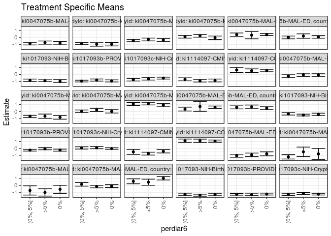

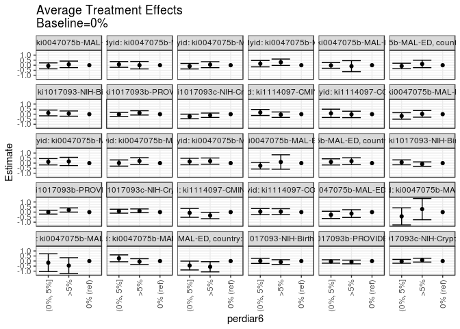

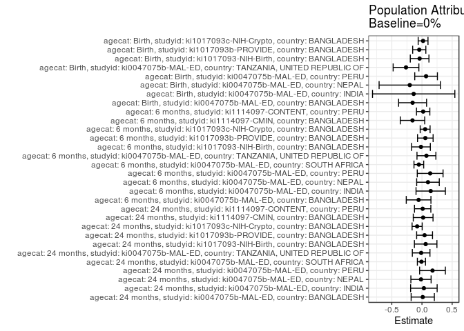

## Results Table

### Parameter: TSM

| agecat | studyid | country | intervention_level | baseline_level | estimate | ci_lower | ci_upper |
| --- | --- | --- | --- | --- | --- | --- | --- |
| Birth | ki0047075b-MAL-ED | BANGLADESH | 0% | NA | -0.7866785 | -1.0744710 | -0.4988860 |
| Birth | ki0047075b-MAL-ED | BANGLADESH | (0%, 5%] | NA | -1.0610116 | -1.2774809 | -0.8445423 |
| Birth | ki0047075b-MAL-ED | BANGLADESH | >5% | NA | -0.9342625 | -1.1909754 | -0.6775496 |
| Birth | ki0047075b-MAL-ED | INDIA | 0% | NA | -0.7950757 | -1.5829191 | -0.0072322 |
| Birth | ki0047075b-MAL-ED | INDIA | (0%, 5%] | NA | -1.2203660 | -1.5340616 | -0.9066704 |
| Birth | ki0047075b-MAL-ED | INDIA | >5% | NA | -0.4994857 | -1.1828249 | 0.1838535 |
| Birth | ki0047075b-MAL-ED | NEPAL | 0% | NA | -0.5662500 | -1.1479485 | 0.0154485 |
| Birth | ki0047075b-MAL-ED | NEPAL | (0%, 5%] | NA | -0.7310000 | -1.3926378 | -0.0693622 |
| Birth | ki0047075b-MAL-ED | NEPAL | >5% | NA | -1.0175000 | -1.5408661 | -0.4941339 |
| Birth | ki0047075b-MAL-ED | PERU | 0% | NA | -0.1200860 | -0.3337393 | 0.0935673 |
| Birth | ki0047075b-MAL-ED | PERU | (0%, 5%] | NA | 0.1503342 | -0.1119910 | 0.4126593 |
| Birth | ki0047075b-MAL-ED | PERU | >5% | NA | -0.1746074 | -0.3620324 | 0.0128176 |
| Birth | ki0047075b-MAL-ED | TANZANIA, UNITED REPUBLIC OF | 0% | NA | 1.0267237 | 0.7746651 | 1.2787824 |
| Birth | ki0047075b-MAL-ED | TANZANIA, UNITED REPUBLIC OF | (0%, 5%] | NA | 0.5809318 | 0.2241245 | 0.9377391 |
| Birth | ki0047075b-MAL-ED | TANZANIA, UNITED REPUBLIC OF | >5% | NA | 0.4568605 | 0.0197288 | 0.8939922 |
| Birth | ki1017093-NIH-Birth | BANGLADESH | 0% | NA | -1.3135546 | -1.4893949 | -1.1377142 |
| Birth | ki1017093-NIH-Birth | BANGLADESH | (0%, 5%] | NA | -1.3006262 | -1.4785166 | -1.1227358 |
| Birth | ki1017093-NIH-Birth | BANGLADESH | >5% | NA | -1.4123893 | -1.5594813 | -1.2652973 |
| Birth | ki1017093b-PROVIDE | BANGLADESH | 0% | NA | -1.2535746 | -1.3865465 | -1.1206026 |
| Birth | ki1017093b-PROVIDE | BANGLADESH | (0%, 5%] | NA | -1.2952008 | -1.4094016 | -1.1809999 |
| Birth | ki1017093b-PROVIDE | BANGLADESH | >5% | NA | -1.3461183 | -1.4814015 | -1.2108352 |
| Birth | ki1017093c-NIH-Crypto | BANGLADESH | 0% | NA | -1.2626685 | -1.3842728 | -1.1410642 |
| Birth | ki1017093c-NIH-Crypto | BANGLADESH | (0%, 5%] | NA | -1.2892985 | -1.4407310 | -1.1378660 |
| Birth | ki1017093c-NIH-Crypto | BANGLADESH | >5% | NA | -1.1742866 | -1.3274078 | -1.0211654 |
| 6 months | ki0047075b-MAL-ED | BANGLADESH | 0% | NA | -0.0819686 | -0.3264566 | 0.1625194 |
| 6 months | ki0047075b-MAL-ED | BANGLADESH | (0%, 5%] | NA | -0.2581959 | -0.4664699 | -0.0499220 |
| 6 months | ki0047075b-MAL-ED | BANGLADESH | >5% | NA | -0.0529090 | -0.2745511 | 0.1687332 |
| 6 months | ki0047075b-MAL-ED | INDIA | 0% | NA | -0.8526963 | -1.1225776 | -0.5828151 |
| 6 months | ki0047075b-MAL-ED | INDIA | (0%, 5%] | NA | -0.7195562 | -0.8757863 | -0.5633260 |
| 6 months | ki0047075b-MAL-ED | INDIA | >5% | NA | -0.6866818 | -0.9916997 | -0.3816640 |

[output cut: 60 more lines]

### Parameter: E(Y)

| agecat | studyid | country | intervention_level | baseline_level | estimate | ci_lower | ci_upper |
| --- | --- | --- | --- | --- | --- | --- | --- |
| Birth | ki0047075b-MAL-ED | BANGLADESH | NA | NA | -0.9418605 | -1.0869834 | -0.7967375 |
| Birth | ki0047075b-MAL-ED | INDIA | NA | NA | -0.9324444 | -1.2067907 | -0.6580982 |
| Birth | ki0047075b-MAL-ED | NEPAL | NA | NA | -0.7684615 | -1.1257770 | -0.4111460 |
| Birth | ki0047075b-MAL-ED | PERU | NA | NA | -0.0520175 | -0.1725298 | 0.0684947 |
| Birth | ki0047075b-MAL-ED | TANZANIA, UNITED REPUBLIC OF | NA | NA | 0.7624348 | 0.5710709 | 0.9537986 |
| Birth | ki1017093-NIH-Birth | BANGLADESH | NA | NA | -1.3525437 | -1.4473932 | -1.2576942 |
| Birth | ki1017093b-PROVIDE | BANGLADESH | NA | NA | -1.2984586 | -1.3752758 | -1.2216415 |
| Birth | ki1017093c-NIH-Crypto | BANGLADESH | NA | NA | -1.2441513 | -1.3281130 | -1.1601897 |
| 6 months | ki0047075b-MAL-ED | BANGLADESH | NA | NA | -0.1376763 | -0.2664642 | -0.0088885 |
| 6 months | ki0047075b-MAL-ED | INDIA | NA | NA | -0.7079979 | -0.8344175 | -0.5815783 |
| 6 months | ki0047075b-MAL-ED | NEPAL | NA | NA | 0.1104308 | -0.0208643 | 0.2417259 |
| 6 months | ki0047075b-MAL-ED | PERU | NA | NA | 1.0528816 | 0.9313005 | 1.1744626 |
| 6 months | ki0047075b-MAL-ED | SOUTH AFRICA | NA | NA | 0.5421785 | 0.3900443 | 0.6943126 |
| 6 months | ki0047075b-MAL-ED | TANZANIA, UNITED REPUBLIC OF | NA | NA | 0.5362213 | 0.4049390 | 0.6675036 |
| 6 months | ki1017093-NIH-Birth | BANGLADESH | NA | NA | -0.4474038 | -0.5378167 | -0.3569909 |
| 6 months | ki1017093b-PROVIDE | BANGLADESH | NA | NA | -0.1990907 | -0.2817968 | -0.1163845 |
| 6 months | ki1017093c-NIH-Crypto | BANGLADESH | NA | NA | 0.0297622 | -0.0491685 | 0.1086930 |
| 6 months | ki1114097-CMIN | BANGLADESH | NA | NA | -0.5780453 | -0.7226627 | -0.4334279 |
| 6 months | ki1114097-CONTENT | PERU | NA | NA | 1.0684318 | 0.9515274 | 1.1853362 |
| 24 months | ki0047075b-MAL-ED | BANGLADESH | NA | NA | -0.8192925 | -0.9412667 | -0.6973182 |
| 24 months | ki0047075b-MAL-ED | INDIA | NA | NA | -0.9516520 | -1.0670654 | -0.8362385 |
| 24 months | ki0047075b-MAL-ED | NEPAL | NA | NA | -0.3749123 | -0.4886073 | -0.2612173 |
| 24 months | ki0047075b-MAL-ED | PERU | NA | NA | 0.1111982 | -0.0118399 | 0.2342362 |
| 24 months | ki0047075b-MAL-ED | SOUTH AFRICA | NA | NA | 0.4090301 | 0.2879441 | 0.5301161 |
| 24 months | ki0047075b-MAL-ED | TANZANIA, UNITED REPUBLIC OF | NA | NA | 0.0547975 | -0.0703378 | 0.1799328 |
| 24 months | ki1017093-NIH-Birth | BANGLADESH | NA | NA | -0.9115790 | -1.0095022 | -0.8136559 |
| 24 months | ki1017093b-PROVIDE | BANGLADESH | NA | NA | -0.8928670 | -0.9755153 | -0.8102187 |
| 24 months | ki1017093c-NIH-Crypto | BANGLADESH | NA | NA | -0.6103502 | -0.7050157 | -0.5156847 |
| 24 months | ki1114097-CMIN | BANGLADESH | NA | NA | -0.8535391 | -0.9644236 | -0.7426546 |
| 24 months | ki1114097-CONTENT | PERU | NA | NA | 0.5668293 | 0.4302437 | 0.7034148 |

### Parameter: ATE

| agecat | studyid | country | intervention_level | baseline_level | estimate | ci_lower | ci_upper |
| --- | --- | --- | --- | --- | --- | --- | --- |
| Birth | ki0047075b-MAL-ED | BANGLADESH | 0% | 0% | 0.0000000 | 0.0000000 | 0.0000000 |
| Birth | ki0047075b-MAL-ED | BANGLADESH | (0%, 5%] | 0% | -0.2743330 | -0.6310407 | 0.0823746 |
| Birth | ki0047075b-MAL-ED | BANGLADESH | >5% | 0% | -0.1475840 | -0.5299582 | 0.2347903 |
| Birth | ki0047075b-MAL-ED | INDIA | 0% | 0% | 0.0000000 | 0.0000000 | 0.0000000 |
| Birth | ki0047075b-MAL-ED | INDIA | (0%, 5%] | 0% | -0.4252903 | -1.2697844 | 0.4192038 |
| Birth | ki0047075b-MAL-ED | INDIA | >5% | 0% | 0.2955900 | -0.7602110 | 1.3513909 |
| Birth | ki0047075b-MAL-ED | NEPAL | 0% | 0% | 0.0000000 | 0.0000000 | 0.0000000 |
| Birth | ki0047075b-MAL-ED | NEPAL | (0%, 5%] | 0% | -0.1647500 | -1.0457368 | 0.7162368 |
| Birth | ki0047075b-MAL-ED | NEPAL | >5% | 0% | -0.4512500 | -1.2337366 | 0.3312366 |
| Birth | ki0047075b-MAL-ED | PERU | 0% | 0% | 0.0000000 | 0.0000000 | 0.0000000 |
| Birth | ki0047075b-MAL-ED | PERU | (0%, 5%] | 0% | 0.2704202 | -0.0699960 | 0.6108363 |
| Birth | ki0047075b-MAL-ED | PERU | >5% | 0% | -0.0545214 | -0.3391752 | 0.2301324 |
| Birth | ki0047075b-MAL-ED | TANZANIA, UNITED REPUBLIC OF | 0% | 0% | 0.0000000 | 0.0000000 | 0.0000000 |
| Birth | ki0047075b-MAL-ED | TANZANIA, UNITED REPUBLIC OF | (0%, 5%] | 0% | -0.4457919 | -0.8840593 | -0.0075245 |
| Birth | ki0047075b-MAL-ED | TANZANIA, UNITED REPUBLIC OF | >5% | 0% | -0.5698632 | -1.0752086 | -0.0645178 |
| Birth | ki1017093-NIH-Birth | BANGLADESH | 0% | 0% | 0.0000000 | 0.0000000 | 0.0000000 |
| Birth | ki1017093-NIH-Birth | BANGLADESH | (0%, 5%] | 0% | 0.0129284 | -0.2373165 | 0.2631732 |
| Birth | ki1017093-NIH-Birth | BANGLADESH | >5% | 0% | -0.0988347 | -0.3287031 | 0.1310336 |
| Birth | ki1017093b-PROVIDE | BANGLADESH | 0% | 0% | 0.0000000 | 0.0000000 | 0.0000000 |
| Birth | ki1017093b-PROVIDE | BANGLADESH | (0%, 5%] | 0% | -0.0416262 | -0.2112453 | 0.1279929 |
| Birth | ki1017093b-PROVIDE | BANGLADESH | >5% | 0% | -0.0925438 | -0.2768355 | 0.0917480 |
| Birth | ki1017093c-NIH-Crypto | BANGLADESH | 0% | 0% | 0.0000000 | 0.0000000 | 0.0000000 |
| Birth | ki1017093c-NIH-Crypto | BANGLADESH | (0%, 5%] | 0% | -0.0266300 | -0.2152270 | 0.1619669 |
| Birth | ki1017093c-NIH-Crypto | BANGLADESH | >5% | 0% | 0.0883819 | -0.1012996 | 0.2780635 |
| 6 months | ki0047075b-MAL-ED | BANGLADESH | 0% | 0% | 0.0000000 | 0.0000000 | 0.0000000 |
| 6 months | ki0047075b-MAL-ED | BANGLADESH | (0%, 5%] | 0% | -0.1762273 | -0.4972259 | 0.1447713 |
| 6 months | ki0047075b-MAL-ED | BANGLADESH | >5% | 0% | 0.0290596 | -0.2992227 | 0.3573420 |
| 6 months | ki0047075b-MAL-ED | INDIA | 0% | 0% | 0.0000000 | 0.0000000 | 0.0000000 |
| 6 months | ki0047075b-MAL-ED | INDIA | (0%, 5%] | 0% | 0.1331402 | -0.1788344 | 0.4451147 |
| 6 months | ki0047075b-MAL-ED | INDIA | >5% | 0% | 0.1660145 | -0.2429939 | 0.5750229 |

[output cut: 60 more lines]

### Parameter: PAR

| agecat | studyid | country | intervention_level | baseline_level | estimate | ci_lower | ci_upper |
| --- | --- | --- | --- | --- | --- | --- | --- |
| Birth | ki0047075b-MAL-ED | BANGLADESH | 0% | NA | -0.1551819 | -0.3867974 | 0.0764335 |
| Birth | ki0047075b-MAL-ED | INDIA | 0% | NA | -0.1373688 | -0.8191609 | 0.5444233 |
| Birth | ki0047075b-MAL-ED | NEPAL | 0% | NA | -0.2022115 | -0.7099692 | 0.3055462 |
| Birth | ki0047075b-MAL-ED | PERU | 0% | NA | 0.0680684 | -0.1195933 | 0.2557302 |
| Birth | ki0047075b-MAL-ED | TANZANIA, UNITED REPUBLIC OF | 0% | NA | -0.2642890 | -0.4773036 | -0.0512743 |
| Birth | ki1017093-NIH-Birth | BANGLADESH | 0% | NA | -0.0389891 | -0.1934123 | 0.1154340 |
| Birth | ki1017093b-PROVIDE | BANGLADESH | 0% | NA | -0.0448841 | -0.1538596 | 0.0640914 |
| Birth | ki1017093c-NIH-Crypto | BANGLADESH | 0% | NA | 0.0185171 | -0.0627561 | 0.0997904 |
| 6 months | ki0047075b-MAL-ED | BANGLADESH | 0% | NA | -0.0557077 | -0.2601245 | 0.1487091 |
| 6 months | ki0047075b-MAL-ED | INDIA | 0% | NA | 0.1446985 | -0.0984473 | 0.3878443 |
| 6 months | ki0047075b-MAL-ED | NEPAL | 0% | NA | 0.0994737 | -0.0876123 | 0.2865596 |
| 6 months | ki0047075b-MAL-ED | PERU | 0% | NA | 0.1356288 | -0.0779753 | 0.3492329 |
| 6 months | ki0047075b-MAL-ED | SOUTH AFRICA | 0% | NA | -0.0518040 | -0.1322455 | 0.0286376 |
| 6 months | ki0047075b-MAL-ED | TANZANIA, UNITED REPUBLIC OF | 0% | NA | 0.0739222 | -0.0825384 | 0.2303827 |
| 6 months | ki1017093-NIH-Birth | BANGLADESH | 0% | NA | -0.0168277 | -0.1721767 | 0.1385213 |
| 6 months | ki1017093b-PROVIDE | BANGLADESH | 0% | NA | 0.0556534 | -0.0732458 | 0.1845526 |
| 6 months | ki1017093c-NIH-Crypto | BANGLADESH | 0% | NA | 0.0523775 | -0.0294953 | 0.1342503 |
| 6 months | ki1114097-CMIN | BANGLADESH | 0% | NA | -0.1570890 | -0.3595054 | 0.0453274 |
| 6 months | ki1114097-CONTENT | PERU | 0% | NA | 0.0199169 | -0.0906616 | 0.1304953 |
| 24 months | ki0047075b-MAL-ED | BANGLADESH | 0% | NA | 0.0128469 | -0.1793806 | 0.2050744 |
| 24 months | ki0047075b-MAL-ED | INDIA | 0% | NA | 0.0318240 | -0.1878380 | 0.2514859 |
| 24 months | ki0047075b-MAL-ED | NEPAL | 0% | NA | -0.0160959 | -0.1835498 | 0.1513580 |
| 24 months | ki0047075b-MAL-ED | PERU | 0% | NA | 0.1745937 | -0.0384882 | 0.3876757 |
| 24 months | ki0047075b-MAL-ED | SOUTH AFRICA | 0% | NA | -0.0086347 | -0.0759944 | 0.0587251 |
| 24 months | ki0047075b-MAL-ED | TANZANIA, UNITED REPUBLIC OF | 0% | NA | -0.0135846 | -0.1595589 | 0.1323897 |
| 24 months | ki1017093-NIH-Birth | BANGLADESH | 0% | NA | 0.0612630 | -0.1251252 | 0.2476512 |
| 24 months | ki1017093b-PROVIDE | BANGLADESH | 0% | NA | 0.0433433 | -0.0881220 | 0.1748087 |
| 24 months | ki1017093c-NIH-Crypto | BANGLADESH | 0% | NA | -0.0799527 | -0.1635958 | 0.0036903 |
| 24 months | ki1114097-CMIN | BANGLADESH | 0% | NA | 0.0195924 | -0.1439681 | 0.1831529 |
| 24 months | ki1114097-CONTENT | PERU | 0% | NA | 0.0117147 | -0.1237682 | 0.1471977 |